# Final Project

## IST3015 End Semester project Created by Michael Ngugi Murei 658267

This is an R Markdown document.

## Importing the dataset

```r
library(readxl)
Yield_Factors_All_Years <- read_excel("C:/Users/REALZ/Documents/IST 3015/Ist 3015 final project/Yield Factors- All Years.xlsx")
Yield_Factors_All_Years
```

```
## # A tibble: 72,354 x 7
##    batch_id Country      Year country_code Land_type  National_Yield World_Yield
##       <dbl> <chr>       <dbl>        <dbl> <chr>               <dbl>       <dbl>
##  1       90 Afghanistan  1961            2 Crop Land            1.32        2.11
##  2       90 Afghanistan  1961            2 Grazing L~           2.67        6.19
##  3       90 Afghanistan  1961            2 Marine Fi~           0         504.
##  4       90 Afghanistan  1961            2 Inland Fi~           0           0
##  5       90 Afghanistan  1961            2 Forest La~           0.64        1.82
##  6       90 Afghanistan  1961            2 Infrastru~           0           0
##  7       90 Afghanistan  1962            2 Crop Land            1.29        2.23
##  8       90 Afghanistan  1962            2 Grazing L~           2.67        6.19
##  9       90 Afghanistan  1962            2 Marine Fi~           0         504.
## 10       90 Afghanistan  1962            2 Inland Fi~           0           0
## # ... with 72,344 more rows
```

## Structure of the Dataset

```r
str(Yield_Factors_All_Years)
```

```
## tibble [72,354 x 7] (S3: tbl_df/tbl/data.frame)
##  $ batch_id      : num [1:72354] 90 90 90 90 90 90 90 90 90 90 ...
##  $ Country       : chr [1:72354] "Afghanistan" "Afghanistan" "Afghanistan" "Afghanistan" ...
##  $ Year          : num [1:72354] 1961 1961 1961 1961 1961 ...
##  $ country_code  : num [1:72354] 2 2 2 2 2 2 2 2 2 2 ...
##  $ Land_type     : chr [1:72354] "Crop Land" "Grazing Land" "Marine Fishing Grounds" "Inland Fishing Grounds" ...
##  $ National_Yield: num [1:72354] 1.32 2.67 0 0 0.64 0 1.29 2.67 0 0 ...
##  $ World_Yield   : num [1:72354] 2.11 6.19 503.84 0 1.82 ...
```

The data set type is a data frame, and contains 72,354 rows with 7 columns. There is the batch id column of Ratio numerical datatype, Country which consists of all Countries and is of Categorical character datatype, Year a Categorical numerical datatype consisting the year in which the yield was measured, Country code represents the numerical code for each country, Land type a Categorical character data type shows the specific area of yield production, National Yield a numerical datatype displays the measurement of yield on a national level and there is World yield that has the measurements of yields on a global scale and is a Interval numeric datatype.

## Grazing land in 2016

```r
library(dplyr)
Yield_Factors_All_Years %>%
  filter(Year == 2016, Land_type == "Grazing Land")
```

```
## # A tibble: 234 x 7
##    batch_id Country      Year country_code Land_type  National_Yield World_Yield
##       <dbl> <chr>       <dbl>        <dbl> <chr>               <dbl>       <dbl>
##  1       90 Afghanistan  2016            2 Grazing L~           2.67        6.19
##  2       90 Albania      2016            3 Grazing L~          11.3         6.19
##  3       90 Algeria      2016            4 Grazing L~           4.38        6.19
##  4       90 American S~  2016            5 Grazing L~           0           6.19
##  5       90 Andorra      2016            6 Grazing L~          11.6         6.19
##  6       90 Angola       2016            7 Grazing L~           7.47        6.19
##  7       90 Anguilla     2016          258 Grazing L~           0           6.19
##  8       90 Antigua an~  2016            8 Grazing L~           0           6.19
##  9       90 Argentina    2016            9 Grazing L~           9.24        6.19
## 10       90 Armenia      2016            1 Grazing L~           9.06        6.19
## # ... with 224 more rows
```

From the data above we notice smaller countries especially those that are islands have zero or low national yield. This could be probably because of not enough area for grazing or climatic conditions are sustainable among other factors. Also we notice that for the year 2016 most of the countries if not all have a World Yield of 6.19 on average.

## Creating new column Yield_Factor

```r
Yield_Factors_All_Years %>%
  mutate(Yield_Factor = National_Yield / World_Yield)
```

```
## # A tibble: 72,354 x 8
##    batch_id Country      Year country_code Land_type  National_Yield World_Yield
##       <dbl> <chr>       <dbl>        <dbl> <chr>               <dbl>       <dbl>
##  1       90 Afghanistan  1961            2 Crop Land            1.32        2.11
##  2       90 Afghanistan  1961            2 Grazing L~           2.67        6.19
##  3       90 Afghanistan  1961            2 Marine Fi~           0         504.
##  4       90 Afghanistan  1961            2 Inland Fi~           0           0
##  5       90 Afghanistan  1961            2 Forest La~           0.64        1.82
##  6       90 Afghanistan  1961            2 Infrastru~           0           0
##  7       90 Afghanistan  1962            2 Crop Land            1.29        2.23
##  8       90 Afghanistan  1962            2 Grazing L~           2.67        6.19
##  9       90 Afghanistan  1962            2 Marine Fi~           0         504.
## 10       90 Afghanistan  1962            2 Inland Fi~           0           0
## # ... with 72,344 more rows, and 1 more variable: Yield_Factor <dbl>
```

This data can show that a yield factor of probably 0.5 and above indicate a good amount of yield is being produced on the particular Land Type sector

## Creating Infrastructure dataset

```r
library(ggplot2)

infrastructure <- Yield_Factors_All_Years %>% filter(Land_type == "Infrastructure")
infrastructure
```

```
## # A tibble: 12,059 x 7
##    batch_id Country      Year country_code Land_type  National_Yield World_Yield
##       <dbl> <chr>       <dbl>        <dbl> <chr>               <dbl>       <dbl>
##  1       90 Afghanistan  1961            2 Infrastru~              0           0
##  2       90 Afghanistan  1962            2 Infrastru~              0           0
##  3       90 Afghanistan  1963            2 Infrastru~              0           0
##  4       90 Afghanistan  1964            2 Infrastru~              0           0
##  5       90 Afghanistan  1965            2 Infrastru~              0           0
##  6       90 Afghanistan  1966            2 Infrastru~              0           0
##  7       90 Afghanistan  1967            2 Infrastru~              0           0
##  8       90 Afghanistan  1968            2 Infrastru~              0           0
##  9       90 Afghanistan  1969            2 Infrastru~              0           0
## 10       90 Afghanistan  1970            2 Infrastru~              0           0
## # ... with 12,049 more rows
```

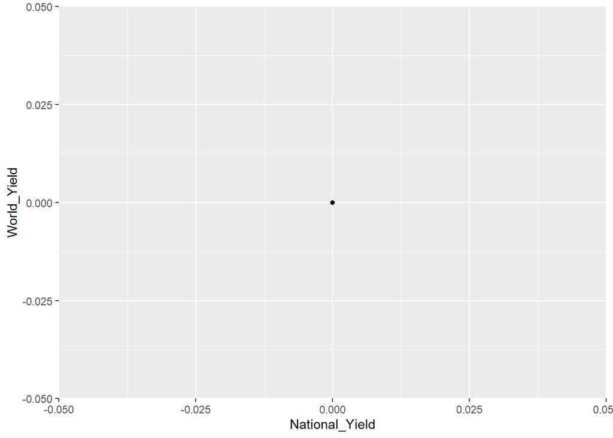

```r
# creating the scatter plot
ggplot(infrastructure, aes(x = National_Yield, y = World_Yield)) +
  geom_point()
```

This data set shows that in the Infrastructure land type there is no yield being produced both on national and global level.

## Scatter plot for year 2016

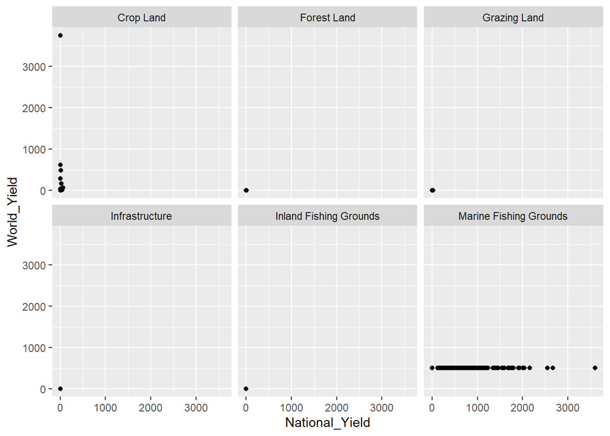

```r
Year_2016 <- Yield_Factors_All_Years %>% filter(Year == 2016) %>%
  group_by(Land_type)

ggplot(Year_2016, aes(x = National_Yield, y = World_Yield)) +
  geom_point() + facet_wrap(~ Land_type)
```

Comparing national yield and world yield for each land type we notice that for the year 2016 forest land, grazing land, infrastructure and inland fishing ground had a poor relationship meaning not a lot of yield was being produced both nationally and globally for each country. For crop land more World yield was being produced than on a national level. We also notice that for Marine Fishing grounds has a relatively constant World yield as the national yield varies.

## Finding median national yield and yield factor

```r
Yield_Factors_All_Years %>%
  group_by(Land_type, Year) %>%
  mutate(Yield_Factor = National_Yield / World_Yield) %>%
  summarize(medianNationalYield = median(National_Yield), medianWorldYield = median(World_Yield), medianYieldFactor = median(Yield_Factor))
```

```
## # A tibble: 336 x 5
## # Groups:   Land_type [6]
##    Land_type  Year medianNationalYield medianWorldYield medianYieldFactor
##    <chr>     <dbl>               <dbl>            <dbl>             <dbl>
##  1 Crop Land  1961                  NA               NA                NA
##  2 Crop Land  1962                  NA               NA                NA
##  3 Crop Land  1963                  NA               NA                NA
##  4 Crop Land  1964                  NA               NA                NA
##  5 Crop Land  1965                  NA               NA                NA
##  6 Crop Land  1966                  NA               NA                NA
##  7 Crop Land  1967                  NA               NA                NA
##  8 Crop Land  1968                  NA               NA                NA
##  9 Crop Land  1969                  NA               NA                NA
## 10 Crop Land  1970                  NA               NA                NA
## # ... with 326 more rows
```

We notice that not all land type for example crop land has been unable to calculate the median probably because the values are too low. For Forest land we are able to obtain median for all columns. Grazing land we are only able to obtain median for world yield only. Infrastructure has median for 0 world and national and is unable to calculate median Yield factor and this goes same for inland fishing ground. For Marine fishing grounds we are able to obtain the median for all values.

## Line plot for Median Yield Factor

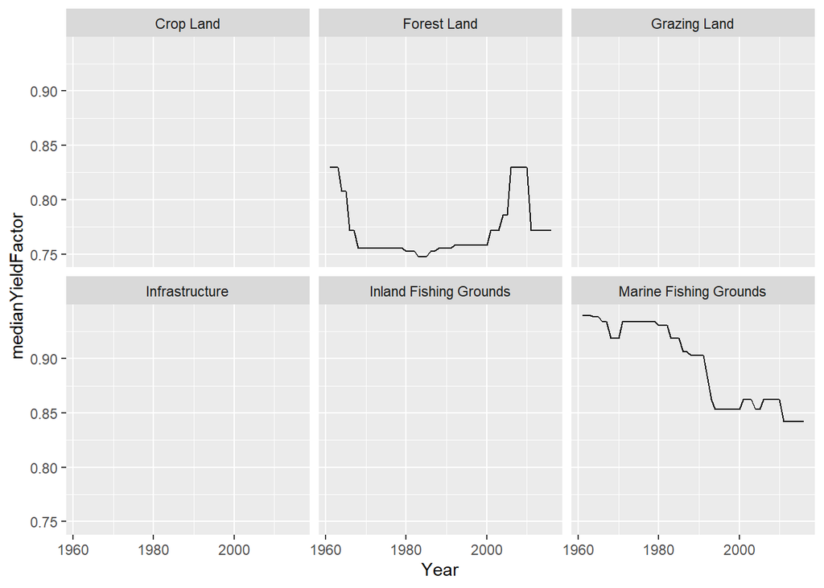

```r
MedianYieldPlot <- Yield_Factors_All_Years %>%
  group_by(Year, Land_type) %>%
  mutate(Yield_Factor = National_Yield / World_Yield) %>%
  summarize(medianYieldFactor = median(Yield_Factor))
ggplot(MedianYieldPlot, aes(x = Year, y = medianYieldFactor)) + geom_line() +
  facet_wrap(~ Land_type)
```